# A4: Análisis estadístico avanzado

Juan Carlos González Joyé

19/06/2018

## 1. Preprocesado.

### 1.1 Carga de datos.

```r
# definimos la ruta del área de trabajo donde está el fichero .csv
setwd("~/RStudio/estad_A4")
library(readr)
fumadores <-read.csv("Fumadores.csv")
head(fumadores)
```

| AE | Tipo |
| --- | --- |
| 4.0100 | NF |
| 4.8772 | NF |
| 4.2927 | NF |
| 4.9475 | NF |
| 4.1266 | NF |
| 4.1926 | NF |

### 1.2 Tipos de datos. Limpieza y transformación.

Comprobamos el tipo de las variables aplicando class() a cada variable del dataframe. En principio los tipos son adeacuados para el tratamiento a realizar.

```r
tipo_variables<-sapply(fumadores, class)
tipo_variables
```

```
##        AE      Tipo
## "numeric"  "factor"
```

Comprobamos con str() si los tipos se corresponden a los del enunciado (6 clases diferentes)

```r
str(fumadores)
```

```
## 'data.frame':    119 obs. of  2 variables:
##  $ AE  : num  4.01 4.88 4.29 4.95 4.13 ...
##  $ Tipo: Factor w/ 8 levels "FI","fL","FL",..: 6 6 6 6 6 6 6 6 6 6 ...
```

```r
summary(fumadores)
```

```
##        AE             Tipo
##  Min.   :1.038   FI     :20
##  1st Qu.:2.519   FM     :20
##  Median :2.954   FP     :20
##  Mean   :3.074   NF     :19
##  3rd Qu.:3.627   FL     :16
##  Max.   :5.284   NI     :16
##                  (Other): 8
```

Vemos que la variable Tipo tiene 8 clases (en vez de las 6 del enunciado), por lo tanto debemos normalizar la nomenclatura utilizada para las clases (poner en mayúsculas)

```r
library(stringr)
fumadores$Tipo<-str_to_upper(fumadores$Tipo)
table(fumadores$Tipo) # vemos datos balanceados en los grupos
```

```
##
## FI FL FM FP NF NI
## 20 19 20 20 19 21
```

```r
# volver a convertir en tipo factor
fumadores$Tipo<-as.factor(fumadores$Tipo)
str(fumadores)
```

```
## 'data.frame':    119 obs. of  2 variables:
##  $ AE  : num  4.01 4.88 4.29 4.95 4.13 ...
##  $ Tipo: Factor w/ 6 levels "FI","FL","FM",..: 5 5 5 5 5 5 5 5 5 5 ...
```

```r
tail(fumadores)
```

|  | AE | Tipo |
| --- | --- | --- |
| 114 | 2.1986 | FI |
| 115 | 2.1249 | FI |
| 116 | 2.6047 | FI |
| 117 | 2.4378 | FI |
| 118 | 2.0082 | FI |
| 119 | 3.1654 | FI |

```r
# comprobar valores perdidos en las variables
 anyNA(fumadores)
```

```
## [1] FALSE
```

### 1.3 Análisis descriptivo en relación a AE

```r
summary(fumadores$AE)
```

```
##    Min. 1st Qu.  Median    Mean 3rd Qu.    Max.
##   1.038   2.519   2.954   3.074   3.627   5.284
```

```r
# estadísticos descriptivos por tipo de fumador
library(psych)
describeBy(fumadores,fumadores$Tipo)
```

```
##
##  Descriptive statistics by group
## group: FI
##       vars  n mean   sd median trimmed  mad  min  max range skew kurtosis
## AE       1 20 2.46 0.55   2.43    2.41 0.47 1.55 3.66  2.11 0.59     -0.3
## Tipo*    2 20 1.00 0.00   1.00    1.00 0.00 1.00 1.00  0.00  NaN      NaN
##         se
## AE    0.12
## Tipo* 0.00
## --------------------------------------------------------
## group: FL
##       vars  n mean   sd median trimmed  mad  min  max range skew kurtosis
## AE       1 19 2.77 0.72   2.85     2.8 0.82 1.04 4.12  3.08 -0.4    -0.17
## Tipo*    2 19 2.00 0.00   2.00     2.0 0.00 2.00 2.00  0.00  NaN      NaN
##         se
## AE    0.16
## Tipo* 0.00
## --------------------------------------------------------
## group: FM
##       vars  n mean   sd median trimmed  mad  min  max range  skew kurtosis
## AE       1 20 2.69 0.66   2.84     2.7 0.51 1.07 4.09  3.02 -0.32     0.31
## Tipo*    2 20 3.00 0.00   3.00     3.0 0.00 3.00 3.00  0.00   NaN      NaN
##         se
## AE    0.15
## Tipo* 0.00
## --------------------------------------------------------
## group: FP
##       vars  n mean   sd median trimmed  mad  min  max range skew kurtosis
## AE       1 20 3.12 0.75   3.06    3.11 0.78 1.75 4.72  2.97 0.11    -0.81
## Tipo*    2 20 4.00 0.00   4.00    4.00 0.00 4.00 4.00  0.00  NaN      NaN
##         se
## AE    0.17
## Tipo* 0.00
## --------------------------------------------------------
## group: NF
##       vars  n mean   sd median trimmed  mad  min  max range  skew kurtosis
## AE       1 19 4.24 0.81   4.29    4.28 0.87 2.52 5.28  2.76 -0.73    -0.43
## Tipo*    2 19 5.00 0.00   5.00    5.00 0.00 5.00 5.00  0.00   NaN      NaN
##         se
## AE    0.19
## Tipo* 0.00
## --------------------------------------------------------
## group: NI
##       vars  n mean  sd median trimmed  mad  min  max range skew kurtosis
## AE       1 21 3.21 0.5   3.08    3.19 0.52 2.48 4.06  1.58 0.26    -1.39
## Tipo*    2 21 6.00 0.0   6.00    6.00 0.00 6.00 6.00  0.00  NaN      NaN
##         se
## AE    0.11
## Tipo* 0.00
```

### 1.4 Analizar datos según tipo de fumador

```r
medias<-aggregate(fumadores,list(fumadores$Tipo),mean)
medias<-medias[1:2]
medias<-medias[order(medias$AE),]  # ordenar las medias asc por AE
head(medias)
```

|  | Group.1 | AE |
| --- | --- | --- |
| 1 | FI | 2.456500 |
| 3 | FM | 2.687775 |
| 2 | FL | 2.773679 |
| 4 | FP | 3.118690 |
| 6 | NI | 3.206190 |
| 5 | NF | 4.240605 |

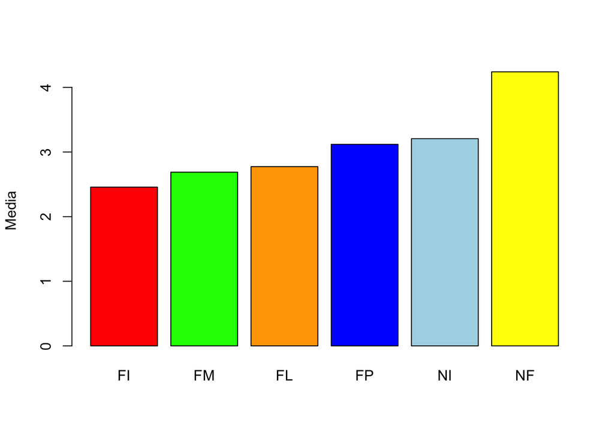

```r
barplot(medias$AE,names.arg =medias$Group.1,
        col=c("red","green","orange","blue","lightblue","yellow"),
        ylab = "Media")
```

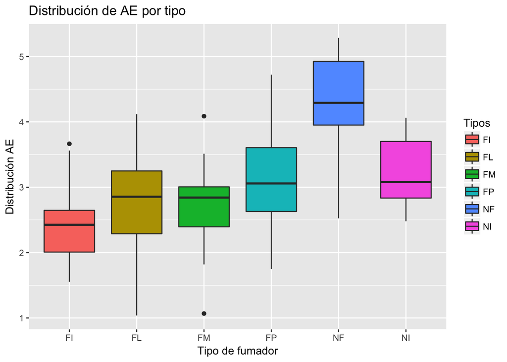

```r
# boxplot con distribucion de AE por tipo

library(ggplot2)
boxpl<-ggplot(fumadores,aes(x=fumadores$Tipo,y=fumadores$AE,fill=fumadores$Tipo)) + geom_boxplot()
boxpl + labs (title="Distribución de AE por tipo",y="Distribución AE",x="Tipo de fumador",fill="Tipos")
```

Comprobamos por lo visto en el gráfico de las cajas de FI y FM, si hay outliers (valores atípicos) ya que podrían influir negativamente en los resultados de ANOVA. Usamos rp.outlier() que aplica la prueba de Lund (1975), indicando si hay valores atípicos y cuáles son.

```r
library(rapportools)
rp.outlier(fumadores[fumadores$Tipo=="FI","AE"])
```

```
## numeric(0)
```

```r
library(rapportools)
rp.outlier(fumadores[fumadores$Tipo=="FM","AE"])
```

```
## numeric(0)
```

No se detectan outliers.

## 2. Intervalo de confianza.

Vamos a definir una función para calcular el IC del nivel de confianza deseado (1-alpha) de un vector x.

```r
IC<-function(x,ic=95) {
  media<-mean(x)
  Desv.Est<-sd(x)
  N<-length(x)
  Error.Est<-Desv.Est/sqrt(N)
  ci.x<-1-(((100-ic)/100)/2)
  Error<-Error.Est* qt(ci.x,df=N-1)
  Lim.Inf<-media-Error
  Lim.Sup<-media+Error
  resultado<-data.frame (media,Desv.Est,N,Error.Est,Error,Lim.Inf,Lim.Sup)
  return(resultado)
}
```

Calculamos el IC (límite inferior y superior) de la capacidad pulmonar (AE) de toda la muestra con nivel de confianza del 95%.

```r
IC(fumadores$AE,ic=95)
```

| media | Desv.Est | N | Error.Est | Error | Lim.Inf | Lim.Sup |
| --- | --- | --- | --- | --- | --- | --- |
| 3.07446 | 0.8704699 | 119 | 0.0797958 | 0.1580175 | 2.916442 | 3.232477 |

## 3. Comparar 2 muestras: Fumadores vs No fumadores

### 3.1 Hipótesis nula y alternativa.

Se trata de poder afirmar que la AE de los fumadores es inferior a la de no fumadores con un nivel de confianza del 95% por ejemplo.

H0: AE fumadores = AE no fumadores

H1: AE fumadores < AE no fumadores

Por lo tanto, se persigue rechazar la hipotesis nula (H0) a favor de la alternativa(H1)

### 3.2 Preparar los datos.

Creamos 2 data frames que contengan las AE de los fumadores (NI,FL,FM y FI) y de los no fumadores (NF,FP).

```r
fumadoresDF<-subset(fumadores,fumadores$Tipo=="NI"|fumadores$Tipo=="FL"|fumadores$Tipo=="FM"|fumadores$Tipo=="FI")
length(fumadoresDF[,2])
```

```
## [1] 80
```

```r
noFumadoresdDF<-subset(fumadores,fumadores$Tipo=="NF"|fumadores$Tipo=="FP")
length(noFumadoresdDF[,2])
```

```
## [1] 39
```

### 3.3 Tipo de contraste.

Contraste unilateral de 2 muestras sobre la diferencia de las medias. Aplicamos el teorema del límite central donde el tamaño de las muestras es >30 entonces la variable se comporta como una normal estándar N(0,1)

### 3.4 Cálculos del valor p

```r
# estadístico contraste

x1bar<-mean(fumadoresDF$AE)
x2bar<-mean(noFumadoresdDF$AE)
n1<-length(fumadoresDF$AE)
n2<-length(noFumadoresdDF$AE)
s1<-sd(fumadoresDF$AE)
s2<-sd(noFumadoresdDF$AE)

sx1.menosx2<-sqrt((s1^2/n1)+(s2^2/n2))
z<-(x1bar-x2bar)/sx1.menosx2 # estadístico de contraste
z
```

```
## [1] -5.169902
```

Calculamos el valor P

```r
pvalue<-pnorm(z)
pvalue
```

```
## [1] 1.171081e-07
```

### 3.5 Interpretar el resultado.

Dado un nivel de confianza por defecto del 95% (0.05), como el valor p=1.171081e-07 es notablemente inferior a 0.05 (p<0.05), rechazamos la H0 a favor de la H1.

## 4. ANOVA.

### 4.1 Verificar asunción de normalidad.

#### 4.1.1 Gráfico de normalidad de la muestra de datos AE.

```r
table(fumadores$Tipo)
```

```
##
## FI FL FM FP NF NI
## 20 19 20 20 19 21
```

Creamos los diferentes gráficos con las muestras por cada tipo.

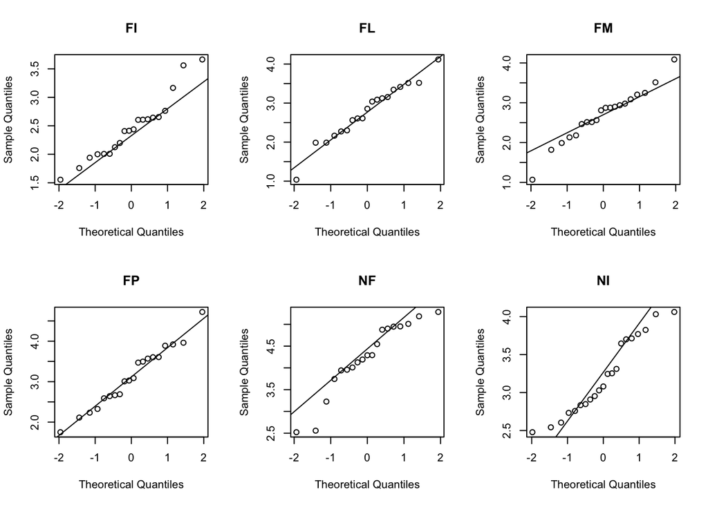

```r
par(mfrow=c(2,3))
qqnorm(fumadores[fumadores$Tipo=="FI","AE"],main = "FI")
qqline(fumadores[fumadores$Tipo=="FI","AE"])

qqnorm(fumadores[fumadores$Tipo=="FL","AE"],main = "FL")
qqline(fumadores[fumadores$Tipo=="FL","AE"])

qqnorm(fumadores[fumadores$Tipo=="FM","AE"],main = "FM")
qqline(fumadores[fumadores$Tipo=="FM","AE"])

qqnorm(fumadores[fumadores$Tipo=="FP","AE"],main = "FP")
qqline(fumadores[fumadores$Tipo=="FP","AE"])

qqnorm(fumadores[fumadores$Tipo=="NF","AE"],main = "NF")
qqline(fumadores[fumadores$Tipo=="NF","AE"])

qqnorm(fumadores[fumadores$Tipo=="NI","AE"],main = "NI")
qqline(fumadores[fumadores$Tipo=="NI","AE"])
```

#### 4.1.2 Hipótesis nula y alternativa.

H0: la distribución es normal

H1: la distribución no es normal

#### 4.1.3 Test de normalidad

Según las recomendaciones de Lopez-Roldán y Fachelli (2015, pag.26), como todas las muestras de datos de los tipos <30 (están entre 19 y 21), para determinar la existencia de normalidad aplicaremos la prueba de Shapiro-Wilk a cada una.

```r
shapiro.test(fumadores[fumadores$Tipo=="FI","AE"])
```

```
##
##  Shapiro-Wilk normality test
##
## data:  fumadores[fumadores$Tipo == "FI", "AE"]
## W = 0.94135, p-value = 0.2542
```

p=0.2542 >0.05 por lo tanto no se rechaza la H0 para FI

```r
shapiro.test(fumadores[fumadores$Tipo=="FL","AE"])
```

```
##
##  Shapiro-Wilk normality test
##
## data:  fumadores[fumadores$Tipo == "FL", "AE"]
## W = 0.97138, p-value = 0.8036
```

p=0.8036 >0.05 por lo tanto no se rechaza la H0 para FL

```r
shapiro.test(fumadores[fumadores$Tipo=="FM","AE"])
```

```
##
##  Shapiro-Wilk normality test
##
## data:  fumadores[fumadores$Tipo == "FM", "AE"]
## W = 0.97184, p-value = 0.7932
```

p=0.7932 > 0.05 por lo tanto no se rechaza la H0 para FM

```r
shapiro.test(fumadores[fumadores$Tipo=="FP","AE"])
```

```
##
##  Shapiro-Wilk normality test
##
## data:  fumadores[fumadores$Tipo == "FP", "AE"]
## W = 0.97617, p-value = 0.8757
```

p=0.8757 > 0.05 por lo tanto no se rechaza la H0 para FP

```r
shapiro.test(fumadores[fumadores$Tipo=="NF","AE"])
```

```
##
##  Shapiro-Wilk normality test
##
## data:  fumadores[fumadores$Tipo == "NF", "AE"]
## W = 0.90888, p-value = 0.07061
```

p=0.07061 > 0.05 por lo tanto no se rechaza la H0 para NF

```r
shapiro.test(fumadores[fumadores$Tipo=="NI","AE"])
```

```
##
##  Shapiro-Wilk normality test
##
## data:  fumadores[fumadores$Tipo == "NI", "AE"]
## W = 0.93296, p-value = 0.1578
```

p=0.1578 > 0.05 por lo tanto no se rechaza la H0 para NI

#### 4.4.4 Intrepretar resultados de gráficos y test.

En los gráficos de cada tipo vemos que los puntos de las muestras se distribuyen de forma alineada a la recta , por lo tanto se aproximan a una normal.

El test de Shapiro-Wilk se emplea para contrastar la normalidad cuando el tamaño de una muestra es menor de 30. Para valor de significación de alfa=0.05, todos los p-valores de cada tipo eran superiores , por lo tanto se cumple la hipotesis nula que los datos si proceden de una distribución normal.

### 4.2 Homoscedasticidad : homogeneidad de varianzas.

#### 4.2.1 Hipotesis nula y alternativa.

Utilizamos el test de Levene basado en la mediana para establecer si las varianzas son iguales o diferentes.

H0: las varianzas son iguales (homoscedasticidad)

H1: las varianzas son diferentes (heteroscedasticidad)

#### 4.2.2 Cálculos

```r
library(car)
leveneTest(AE ~ Tipo, fumadores, center=median)
```

|  | Df | F value | Pr(>F) |
| --- | --- | --- | --- |
| group | 5 | 0.997015 | 0.4229455 |
|  | 113 | NA | NA |

#### 4.2.3 Interpretar resultados

No hay envidencias según el test de falta de homoscedasticidad, Pr=0.4229 > 0.05 , por lo tanto aceptamos la H0, las varianzas son iguales.

### 4.3 ANOVA unifactorial (One Way ANOVA)

#### 4.3.1 Hipotesis nula y alternativa

Vamos a poner a prueba si existen diferencias significativas en el nivel de aire expulsado (AE) entre los diferentes tipos de fumadores. O lo que es lo mismo si existen o no diferencias significativas entre las medias de la variable dependiente para cada grupo.

H0: las medias de todas las muestras son iguales

H1: al menos una de las medias es diferente del resto

#### 4.3.2 Calcular con aov()

```r
anova_uni<-aov(fumadores$AE  ~ fumadores$Tipo,data = fumadores )
summary(anova_uni)
```

```
##                 Df Sum Sq Mean Sq F value   Pr(>F)
## fumadores$Tipo   5  38.59   7.718   17.16 1.33e-12 ***
## Residuals      113  50.82   0.450
## ---
## Signif. codes:  0 '***' 0.001 '**' 0.01 '*' 0.05 '.' 0.1 ' ' 1
```

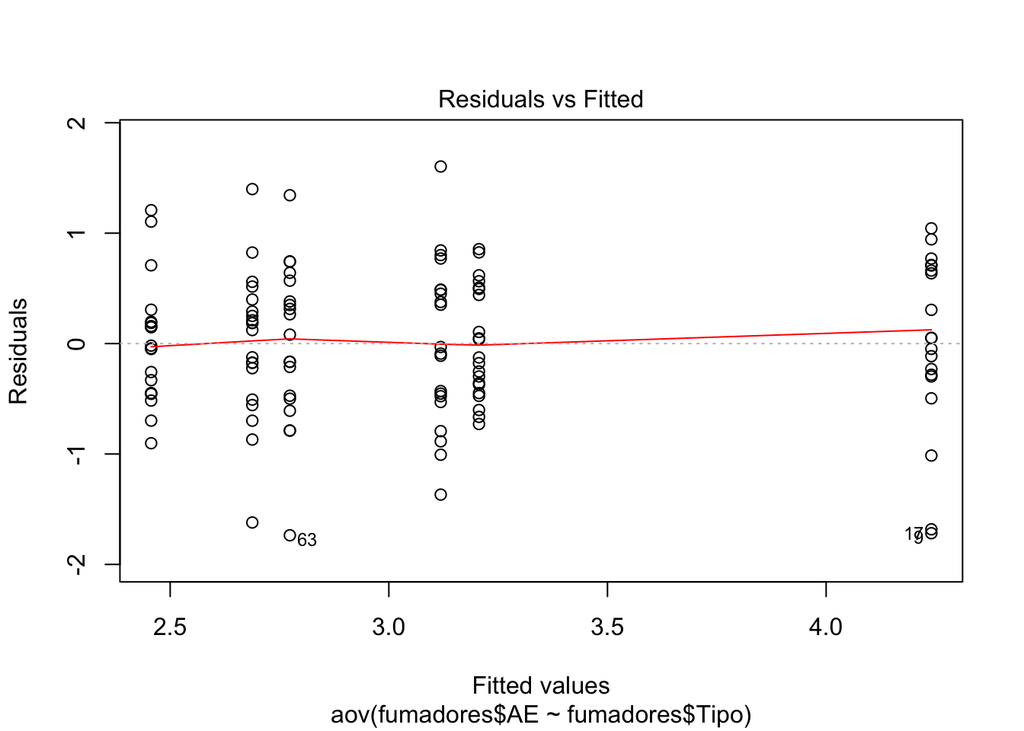

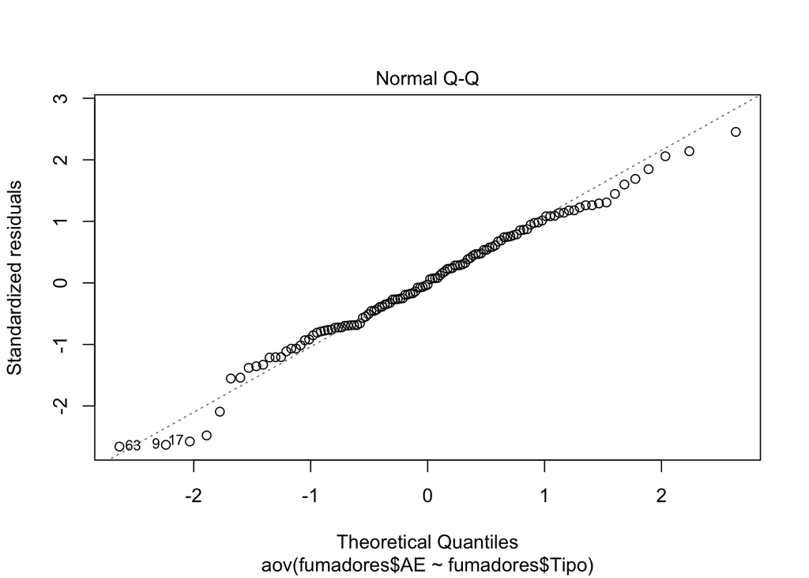

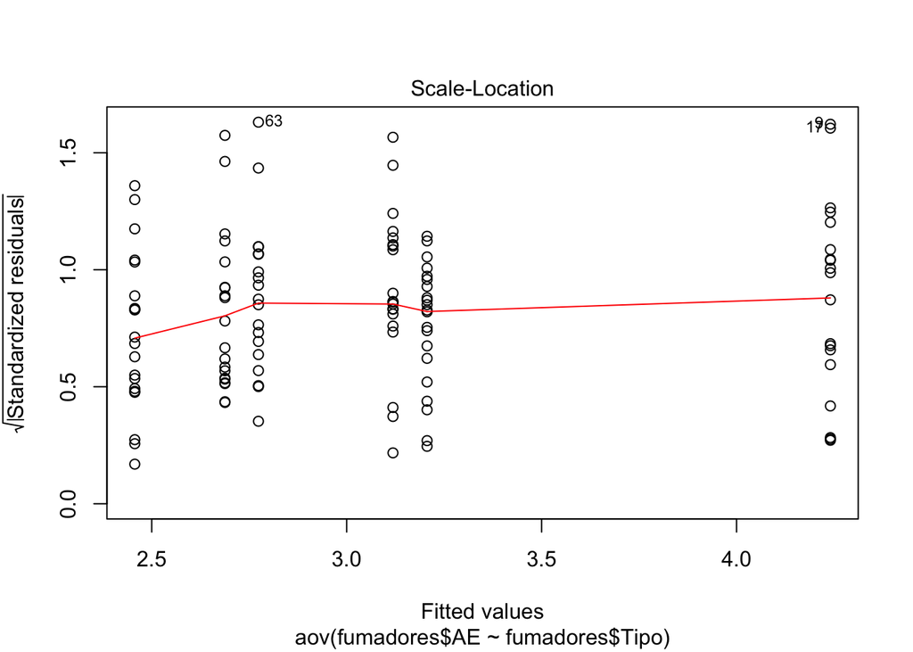

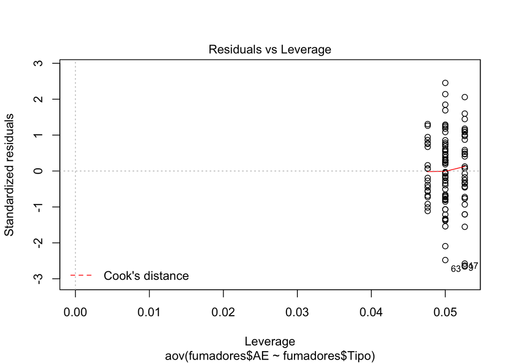

```r
plot(anova_uni)
```

#### 4.3.3 Interpretar resultados

Según López-Roldan y Fachelli (pag.34) , si el valor de la prueba estadística F es 1 o menor, entonces la varianza intergrupos es menor que la intragrupos, las diferencias dentro de cada grupo son mayores que entre ellos. En esta situación se deduce, que las medias no son significativamente distintas y se acepta la hipótesis nula (H0).

En este caso, F=17.16 , se rechaza la H0, aceptando la H1, por lo tanto sabemos que existen diferencias entre las medias, y por lo menos una de ellas es diferente al resto. El objetivo será establecer entre que tipos se dan las diferencias y como se relacionan las variables. También se constata que la Pr(>F) < 0.05 por tanto se da la H1.

En el gráfico boxplot de 1.4 se puede apreciar como algunos tipos por ejemplo tienen medias similares (FL, FM, FP) y NF difiere del resto de tipos considerablemente con valor superior de AE

### 4.4 Cálculos ANOVA.

#### 4.4.1 Identificar variables.

SST (varianza muestra total) = SSW + SSB

SSB= 38.59 (variación entre grupos) valor de variable independiente SSW= 50.82 (variación intra grupos) valor residual

grados de libertad (5,113):

SST = N-1 SSB = k-1 (k=numero de niveles del factor, en este caso los tipos 6 ) SSW = N-k

VE = SBB/k-1 Cuadrados medios del Factor (intervarianza) VI = SSW/N-k Cuadrados medios del Error (intravarianza)

F = VE/VI

```r
N<-119
k<-6

SSB<-38.59
SSW<-50.82

VE<-SSB/(k-1)
VI<-SSW/(N-k)
F<-VE/VI

VE
```

```
## [1] 7.718
```

```r
VI
```

```
## [1] 0.4497345
```

```r
F
```

```
## [1] 17.16124
```

#### 4.4.2 Calcular manualmente las variables

```r
sumaAE<- sum(fumadores$AE)
N=119
overallmean <-sumaAE/N

nFI<-nrow(fumadores[fumadores$Tipo=="FI",])
nFM<-nrow(fumadores[fumadores$Tipo=="FM",])
nFL<-nrow(fumadores[fumadores$Tipo=="FL",])
nFP<-nrow(fumadores[fumadores$Tipo=="FP",])
nNI<-nrow(fumadores[fumadores$Tipo=="NI",])
nNF<-nrow(fumadores[fumadores$Tipo=="NF",])


FImean<-mean(fumadores$AE[fumadores$Tipo=="FI"])
FMmean<-mean(fumadores$AE[fumadores$Tipo=="FM"])
FLmean<-mean(fumadores$AE[fumadores$Tipo=="FL"])
FPmean<-mean(fumadores$AE[fumadores$Tipo=="FP"])
NImean<-mean(fumadores$AE[fumadores$Tipo=="NI"])
NFmean<-mean(fumadores$AE[fumadores$Tipo=="NF"])

ssb<-sum(nFI * (FImean - overallmean)^2 +
         nFM * (FMmean - overallmean)^2 +
         nFL * (FLmean - overallmean)^2 +
         nFP * (FPmean - overallmean)^2 +
         nNI * (NImean - overallmean)^2 +
         nNF * (NFmean - overallmean)^2)


ssw<- sum(c((fumadores[fumadores$Tipo=="FI", "AE"] - FImean)^2,
            (fumadores[fumadores$Tipo=="FM", "AE"] - FMmean)^2,
            (fumadores[fumadores$Tipo=="FL", "AE"] - FLmean)^2,
            (fumadores[fumadores$Tipo=="FP", "AE"] - FPmean)^2,
            (fumadores[fumadores$Tipo=="NI", "AE"] - NImean)^2,
            (fumadores[fumadores$Tipo=="NF", "AE"] - NFmean)^2))

cat ("ssb : ", ssb, "ssw : ", ssw, "  sst :", ssb+ssw)
```

```
## ssb :  38.58845 ssw :  50.82225   sst : 89.4107
```

### 4.5 Calcular la fuerza de relación e interpretar.

η2 (eta cuadrado) mide la parte explicada por la variable independiente, y su valor se encuentra entre 0 y 1. Su formula es η2=SCefecto / SCtotal y los valores se pueden obtener del summary del ANOVA (ssb y ssw)

```r
eta_cuadrado <-ssb / (ssb + ssw)
eta_cuadrado
```

```
## [1] 0.4315865
```

```r
library(lsr)
etaSquared(anova_uni)
```

```
##                   eta.sq eta.sq.part
## fumadores$Tipo 0.4315865   0.4315865
```

Cuando en el modelo solo disponemos de una variable independiente su valor dificilmente supera el 50% de variabilidad explicada, como vemos en este ejemplo.

## 5. Comparaciones múltiples.

### 5.1 Sin corrección.

```r
test1<-pairwise.t.test(x=fumadores$AE, g=fumadores$Tipo, p.adjust.method = "none")
test1
```

```
##
##  Pairwise comparisons using t tests with pooled SD
##
## data:  fumadores$AE and fumadores$Tipo
##
##    FI      FL      FM      FP      NF
## FL 0.14264 -       -       -       -
## FM 0.27780 0.69003 -       -       -
## FP 0.00228 0.11110 0.04451 -       -
## NF 2.5e-13 6.9e-10 6.2e-11 8.2e-07 -
## NI 0.00051 0.04400 0.01484 0.67704 3.6e-06
##
## P value adjustment method: none
```

### 5.2 Corrección de Bonferroni

```r
test2<-pairwise.t.test(x=fumadores$AE, g=fumadores$Tipo, p.adjust.method = "bonferroni")
test2
```

```
##
##  Pairwise comparisons using t tests with pooled SD
##
## data:  fumadores$AE and fumadores$Tipo
##
##    FI      FL      FM      FP      NF
## FL 1.0000  -       -       -       -
## FM 1.0000  1.0000  -       -       -
## FP 0.0342  1.0000  0.6676  -       -
## NF 3.7e-12 1.0e-08 9.3e-10 1.2e-05 -
## NI 0.0077  0.6600  0.2226  1.0000  5.5e-05
##
## P value adjustment method: bonferroni
```

Con el ajuste de Bonferroni hay más pares de tipos que no son estadísticamente significativos (p > 0.05) que sin la corrección. Este es un test más conservador que sin corrección. El ajuste de Bonferroni divide los errores de Tipo I con ratio (0.05) por el numero de test realizados.

### 5.3 Prueba de Scheffé

```r
library(DescTools)
sc<-ScheffeTest(anova_uni)
sc
```

```
##
##   Posthoc multiple comparisons of means : Scheffe Test
##     95% family-wise confidence level
##
## $`fumadores$Tipo`
##              diff      lwr.ci     upr.ci    pval
## FL-FI  0.31717895 -0.41054995  1.0449078 0.82268
## FM-FI  0.23127500 -0.48706345  0.9496134 0.94500
## FP-FI  0.66219000 -0.05614845  1.3805284 0.09157 .
## NF-FI  1.78410526  1.05637637  2.5118342 1.6e-10 ***
## NI-FI  0.74969048  0.03995519  1.4594258 0.03108 *
## FM-FL -0.08590395 -0.81363284  0.6418249 0.99947
## FP-FL  0.34501105 -0.38271784  1.0727399 0.76389
## NF-FL  1.46692632  0.72992662  2.2039260 2.7e-07 ***
## NI-FL  0.43251153 -0.28672653  1.1517496 0.53111
## FP-FM  0.43091500 -0.28742345  1.1492534 0.53392
## NF-FM  1.55283026  0.82510137  2.2805592 2.9e-08 ***
## NI-FM  0.51841548 -0.19131981  1.2281508 0.30238
## NF-FP  1.12191526  0.39418637  1.8496442 0.00016 ***
## NI-FP  0.08750048 -0.62223481  0.7972358 0.99935
## NI-NF -1.03441479 -1.75365285 -0.3151767 0.00057 ***
##
## ---
## Signif. codes:  0 '***' 0.001 '**' 0.01 '*' 0.05 '.' 0.1 ' ' 1
```

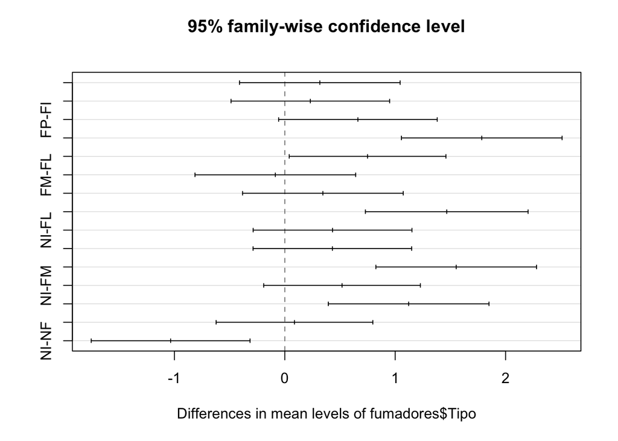

```r
plot(sc)
```

## 6. ANOVA multifactorial.

### 6.1.1 Análisis visual

```r
# leer nuevo conjunto de datos con variables independientes sexo y tipo
fumadores2<-read.csv("Fumadores2.csv")
head(fumadores2)
```

| AE | Tipo | Sex |
| --- | --- | --- |
| 3.607107 | NF | M |
| 3.708264 | NF | M |
| 3.824298 | NF | M |
| 3.355295 | NF | M |
| 3.921486 | NF | M |
| 3.195607 | NF | M |

```r
summary(fumadores2)
```

```
##        AE         Tipo     Sex
##  Min.   :0.5306   FI: 54   F:252
##  1st Qu.:2.6642   FL: 62   M:250
##  Median :3.2370   FM: 46
##  Mean   :3.1329   FP:100
##  3rd Qu.:3.6826   NF:100
##  Max.   :5.3123   NI:140
```

```r
mediasMulti<-aggregate(fumadores2,list(fumadores2$Tipo,fumadores2$Sex),mean)
mediasMulti<-mediasMulti[0:3]
mediasMulti
```

| Group.1 | Group.2 | AE |
| --- | --- | --- |
| FI | F | 2.153394 |
| FL | F | 2.743544 |
| FM | F | 2.282694 |
| FP | F | 3.301332 |
| NF | F | 3.641762 |
| NI | F | 3.163780 |
| FI | M | 2.486166 |
| FL | M | 3.037663 |
| FM | M | 2.574741 |
| FP | M | 3.406332 |
| NF | M | 3.748391 |
| NI | M | 3.292063 |

Vamos primero a generar diagramas boxplot para identificar visualmente posibles diferencias significativas, asimetrias, valores atípicos y homogeneidad de varianza entre los diferentes factores.

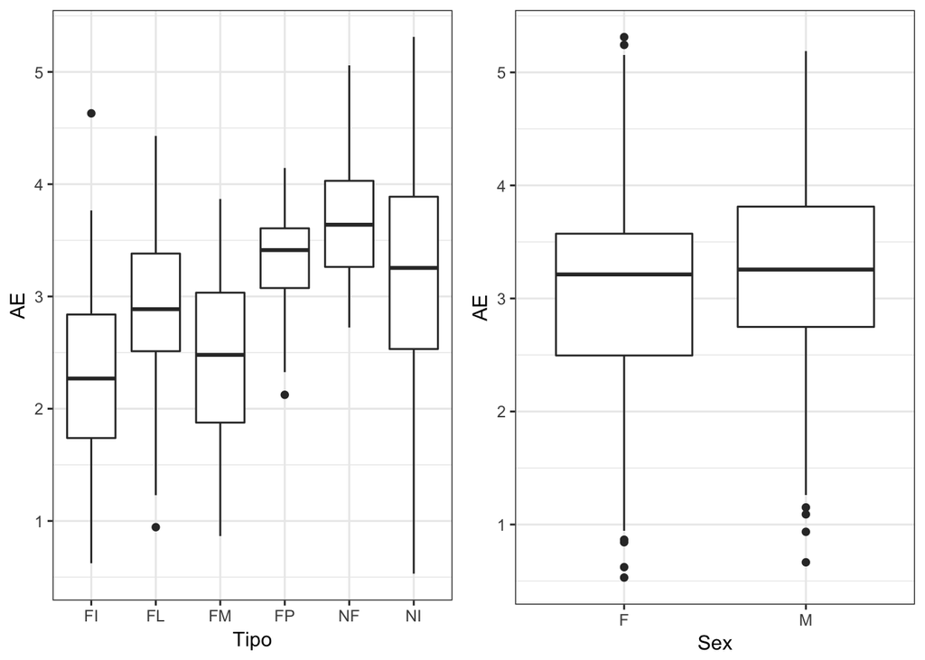

```r
library(ggplot2)
library(gridExtra)

p1 <- ggplot(data = fumadores2, mapping = aes(x = Tipo, y = AE)) + geom_boxplot() +
    theme_bw()
p2 <- ggplot(data = fumadores2, mapping = aes(x = Sex, y = AE)) + geom_boxplot() +
    theme_bw()
p3 <- ggplot(data = fumadores2, mapping = aes(x = Tipo, y = AE, colour = Sex)) +
    geom_boxplot() + theme_bw()

grid.arrange(p1, p2, ncol = 2)
```

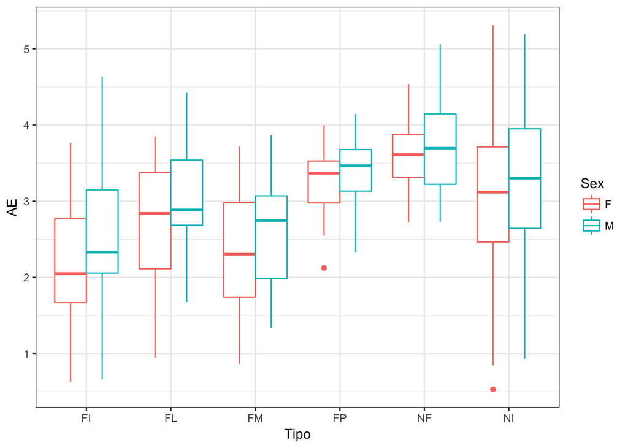

```r
p3
```

Creamos los gráficos de interacción (perfil) para analizar visualmente la posible interacción o no de las variables. Se busca explicar el valor AE según sexo y tipo de fumador.

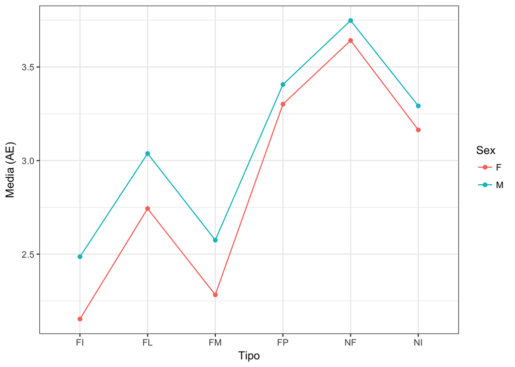

```r
ggplot(data = fumadores2, aes(x = Tipo, y = AE, colour = Sex, group = Sex)) +
    stat_summary(fun.y = mean, geom = "point") + stat_summary(fun.y = mean,
    geom = "line") + labs(y = "Media (AE)") + theme_bw()
```

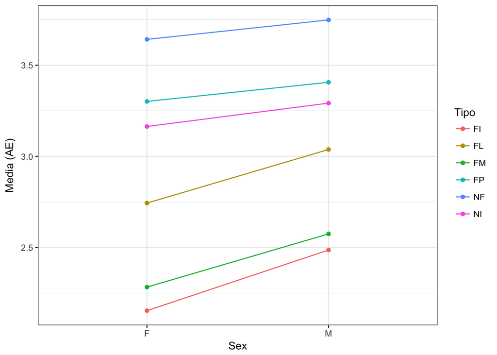

```r
ggplot(data = fumadores2, aes(x = Sex, y = AE, colour = Tipo, group = Tipo)) +
    stat_summary(fun.y = mean, geom = "point") + stat_summary(fun.y = mean,
    geom = "line") + labs(y = "Media (AE)") + theme_bw()
```

Los gráficos muestran la existencia de medias distintas según los valores de cada variable (los puntos del gráfico) y líneas que marcan las tendencias de asociación.Cuando las líneas se mantienen paralelas estamos en situaciones de ausencia de interacción. Cuando las líneas se cruzan o cambian la pendiente estamos ante situaciones que pueden ser de interacción.

En este caso se puede observar que las lineas se mantienen paralelas , por tanto se puede deducir ausencia de interacción entre las variables, solo efectos principales. Por jemplo , los tipos se mantienen proporcionales entre ambos sexos.

### 6.1.2 ANOVA multifactorial

```r
anova_multi<-aov(formula = AE ~ Tipo*Sex, data=fumadores2)
summary(anova_multi)
```

```
##              Df Sum Sq Mean Sq F value  Pr(>F)
## Tipo          5 100.05  20.009  37.222 < 2e-16 ***
## Sex           1   3.92   3.922   7.297 0.00715 **
## Tipo:Sex      5   1.03   0.206   0.383 0.86069
## Residuals   490 263.40   0.538
## ---
## Signif. codes:  0 '***' 0.001 '**' 0.01 '*' 0.05 '.' 0.1 ' ' 1
```

El análisis de la varianza indica que existe influencia significativa sobre la cantidad de aire expulsado (AE) por parte de ambos factores (Tipo y Sex) , pero que no existe interacción significativa entre ellos (Tipo:Sex).

## 7. Aplicación ANOVA en minería datos.

### 7.1 Carga de datos

```r
library(mlbench)
data(BreastCancer)
BC<-BreastCancer
summary(BC)
```

```
##       Id             Cl.thickness   Cell.size     Cell.shape
##  Length:699         1      :145   1      :384   1      :353
##  Class :character   5      :130   10     : 67   2      : 59
##  Mode  :character   3      :108   3      : 52   10     : 58
##                     4      : 80   2      : 45   3      : 56
##                     10     : 69   4      : 40   4      : 44
##                     2      : 50   5      : 30   5      : 34
##                     (Other):117   (Other): 81   (Other): 95
##  Marg.adhesion  Epith.c.size  Bare.nuclei   Bl.cromatin  Normal.nucleoli
##  1      :407   2      :386   1      :402   2      :166   1      :443
##  2      : 58   3      : 72   10     :132   3      :165   10     : 61
##  3      : 58   4      : 48   2      : 30   1      :152   3      : 44
##  10     : 55   1      : 47   5      : 30   7      : 73   2      : 36
##  4      : 33   6      : 41   3      : 28   4      : 40   8      : 24
##  8      : 25   5      : 39   (Other): 61   5      : 34   6      : 22
##  (Other): 63   (Other): 66   NA's   : 16   (Other): 69   (Other): 69
##     Mitoses          Class
##  1      :579   benign   :458
##  2      : 35   malignant:241
##  3      : 33
##  10     : 14
##  4      : 12
##  7      :  9
##  (Other): 17
```

```r
head(BC)
```

| Id | Cl.thickness | Cell.size | Cell.shape | Marg.adhesion | Epith.c.size | Bare.nuclei | Bl.cromatin | Normal.nucleoli | Mitoses | Class |
| --- | --- | --- | --- | --- | --- | --- | --- | --- | --- | --- |
| 1000025 | 5 | 1 | 1 | 1 | 2 | 1 | 3 | 1 | 1 | benign |
| 1002945 | 5 | 4 | 4 | 5 | 7 | 10 | 3 | 2 | 1 | benign |
| 1015425 | 3 | 1 | 1 | 1 | 2 | 2 | 3 | 1 | 1 | benign |
| 1016277 | 6 | 8 | 8 | 1 | 3 | 4 | 3 | 7 | 1 | benign |
| 1017023 | 4 | 1 | 1 | 3 | 2 | 1 | 3 | 1 | 1 | benign |
| 1017122 | 8 | 10 | 10 | 8 | 7 | 10 | 9 | 7 | 1 | malignant |

### 7.2 Crear conjunto de datos

```r
library(caret)

BC_set<-BC[c(2,3,4,6,11)]
head (BC_set)
```

| Cl.thickness | Cell.size | Cell.shape | Epith.c.size | Class |
| --- | --- | --- | --- | --- |
| 5 | 1 | 1 | 2 | benign |
| 5 | 4 | 4 | 7 | benign |
| 3 | 1 | 1 | 2 | benign |
| 6 | 8 | 8 | 3 | benign |
| 4 | 1 | 1 | 2 | benign |
| 8 | 10 | 10 | 7 | malignant |

```r
anyNA(BC_set) # comprobar si hay valores NA antes de aplicar KNN
```

```
## [1] FALSE
```

### 7.3 Validación cruzada

```r
# Crear 5 divisiones (Folds)
folds<-createFolds(factor(BC_set$Class),k=5, list=TRUE)
str(folds)
```

```
## List of 5
##  $ Fold1: int [1:139] 1 12 17 20 26 34 40 42 44 46 ...
##  $ Fold2: int [1:140] 5 6 9 11 15 19 28 35 36 38 ...
##  $ Fold3: int [1:141] 10 13 14 23 24 27 31 32 33 48 ...
##  $ Fold4: int [1:139] 2 3 7 18 21 22 25 30 39 50 ...
##  $ Fold5: int [1:140] 4 8 16 29 37 41 43 45 49 54 ...
```

```r
sapply(folds, length)
```

```
## Fold1 Fold2 Fold3 Fold4 Fold5
##   139   140   141   139   140
```

```r
# ejemplo del primer fold con su conjunto train y test según lista de indices createFolds
testf1<-BC_set[folds[[1]],]
trainf1<-BC_set[-folds[[1]],]

dim(trainf1)
```

```
## [1] 560   5
```

```r
dim(testf1)
```

```
## [1] 139   5
```

```r
sapply(folds, function(i) table(BC_set$Class[i])) # representación de etiquetas por cada fold
```

```
##           Fold1 Fold2 Fold3 Fold4 Fold5
## benign       91    92    92    91    92
## malignant    48    48    49    48    48
```

### 7.4 Cálculo de precisión

```r
# Usando knn3 y predict

# listas para guardar los modelos de entrenamientos y predicciones
knn_fit_list<-list()
knn_pred_list<-list()

# Preparar el dataframe para análisis ANOVA
anova_df<-data.frame(fold=factor(),
                     K=factor(),
                     precision=double())

# Bucle por cada fold y diferente valor de K , entrenar + predecir + precisión
for (f in 1:5) {
  for (K in c(3,5,7)) {
    knn_fit_list[[K]]<-knn3(Class ~ .,data = BC_set[-folds[[f]],], k=K)

    knn_pred_list[[K]]<-predict(knn_fit_list[[K]],newdata= BC_set[folds[[f]],], type="class")

    accu<-confusionMatrix(knn_pred_list[[K]],BC_set$Class[folds[[f]]])$overall['Accuracy']

    #cat("F:",f,"K:",K, "Accuracy:",accu, "\n")
    anova_df<-rbind(anova_df,c(f,K,accu)) # insertar en el dataframe
  }
}

print(anova_df)
```

```
##    X1 X3 X0.956834532374101
## 1   1  3          0.9568345
## 2   1  5          0.9568345
## 3   1  7          0.9568345
## 4   2  3          0.9571429
## 5   2  5          0.9642857
## 6   2  7          0.9642857
## 7   3  3          0.9574468
## 8   3  5          0.9574468
## 9   3  7          0.9645390
## 10  4  3          0.9424460
## 11  4  5          0.9496403
## 12  4  7          0.9424460
## 13  5  3          0.9500000
## 14  5  5          0.9500000
## 15  5  7          0.9428571
```

```r
# usando trainControl + train (caret) también se puede encontrar la k optima con CV

ctrl<-trainControl(method = "cv", index = folds, number=5,savePredictions ="all")

modelo<-train(Class ~ ., data = BC_set, method="knn",trControl=ctrl, metric="Accuracy",tuneLength=20)
modelo
```

```
## k-Nearest Neighbors
##
## 699 samples
##   4 predictor
##   2 classes: 'benign', 'malignant'
##
## No pre-processing
## Resampling: Cross-Validated (5 fold)
## Summary of sample sizes: 139, 140, 141, 139, 140
## Resampling results across tuning parameters:
##
##   k   Accuracy   Kappa
##    5  0.9413403  0.8691568
##    7  0.9406228  0.8675389
##    9  0.9352619  0.8553048
##   11  0.9313237  0.8458154
##   13  0.9248900  0.8304526
##   15  0.9191738  0.8163387
##   17  0.9123766  0.7990159
##   19  0.9037930  0.7777504
##   21  0.8973606  0.7615228
##   23  0.8930666  0.7502408
##   25  0.8859109  0.7321368
##   27  0.8766201  0.7073569
##   29  0.8709013  0.6927387
##   31  0.8594549  0.6618941
##   33  0.8487259  0.6332274
##   35  0.8397756  0.6094515
##   37  0.8304834  0.5829035
##   39  0.8186722  0.5498815
##   41  0.8036511  0.5049008
##   43  0.7829099  0.4426185
##
## Accuracy was used to select the optimal model using the largest value.
## The final value used for the model was k = 5.
```

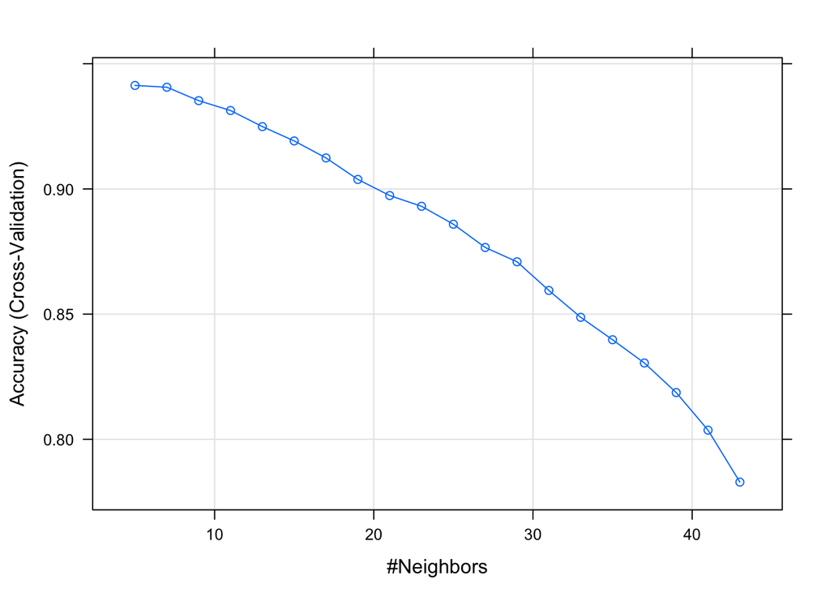

```r
plot(modelo)
```

### 7.5 Preparar datos para análisis de varianza.

Ya disponemos en el dataframe “anova_df” los datos de precisión (accuracy) de aplicar los diferentes valores de K en los conjuntos de cada fold.

Para el análisis de la varianza usaremos las columnas Precisión y k como factor para valorar si hay diferencias al aplicar el modelo con los diferentes valores de K , y en caso de haberlas cual es el mejor valor.

```r
colnames(anova_df)[1]<-"Fold"
colnames(anova_df)[2]<-"K"
colnames(anova_df)[3]<-"Precision"
anova_df$K<-as.factor(anova_df$K)
anova_df
```

| Fold | K | Precision |
| --- | --- | --- |
| 1 | 3 | 0.9568345 |
| 1 | 5 | 0.9568345 |
| 1 | 7 | 0.9568345 |
| 2 | 3 | 0.9571429 |
| 2 | 5 | 0.9642857 |
| 2 | 7 | 0.9642857 |
| 3 | 3 | 0.9574468 |
| 3 | 5 | 0.9574468 |
| 3 | 7 | 0.9645390 |
| 4 | 3 | 0.9424460 |
| 4 | 5 | 0.9496403 |
| 4 | 7 | 0.9424460 |
| 5 | 3 | 0.9500000 |
| 5 | 5 | 0.9500000 |
| 5 | 7 | 0.9428571 |

```r
medias_K<-aggregate(anova_df,list(anova_df$K),mean)
head(medias_K)
```

| Group.1 | Fold | K | Precision |
| --- | --- | --- | --- |
| 3 | 3 | NA | 0.9527740 |
| 5 | 3 | NA | 0.9556415 |
| 7 | 3 | NA | 0.9541925 |

### 7.6 Asunciones ANOVA

Vamos a testear si se cumple normalidad y homoscedasticidad.

```r
table(anova_df$K)
```

```
##
## 3 5 7
## 5 5 5
```

La muestra tiene pocas observaciones y lógicamente están balanceadas para cada tipo de K que hemos aplicado

Vamos a realizar una inspección visual de la muestra de datos de K con qqnorm .

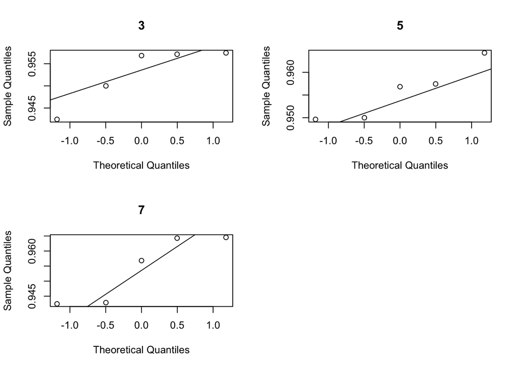

```r
par(mfrow=c(2,2))

qqnorm(anova_df[anova_df$K=="3","Precision"],main="3")
qqline(anova_df[anova_df$K=="3","Precision"])

qqnorm(anova_df[anova_df$K=="5","Precision"],main="5")
qqline(anova_df[anova_df$K=="5","Precision"])

qqnorm(anova_df[anova_df$K=="7","Precision"],main="7")
qqline(anova_df[anova_df$K=="7","Precision"])
```

H0: la distribución es normal

H1: la distribución no es normal

Dado que cada grupo de k tiene <30 observaciones (solo 5) , siguiendo las indicaciones de Lopez-Roldán y Fachelli (2015, pag.26) aplicamos el test de Shapiro-Wilk a cada grupo para determinar la existencia de normalidad.

```r
shapiro.test(anova_df[anova_df$K=="3","Precision"])
```

```
##
##  Shapiro-Wilk normality test
##
## data:  anova_df[anova_df$K == "3", "Precision"]
## W = 0.79613, p-value = 0.07532
```

```r
shapiro.test(anova_df[anova_df$K=="5","Precision"])
```

```
##
##  Shapiro-Wilk normality test
##
## data:  anova_df[anova_df$K == "5", "Precision"]
## W = 0.90305, p-value = 0.427
```

```r
shapiro.test(anova_df[anova_df$K=="7","Precision"])
```

```
##
##  Shapiro-Wilk normality test
##
## data:  anova_df[anova_df$K == "7", "Precision"]
## W = 0.81732, p-value = 0.1113
```

Comprobamos la condición de homoscedasticidad (varianzas homogeneas). Utilizamos el test de Levene.

H0: las varianzas son iguales (se cumple homoscedasticidad)

H1 : las varianzas no son iguales (heteroscedasticidad)

```r
library(car)
leveneTest(Precision ~ K, anova_df, center="median")
```

|  | Df | F value | Pr(>F) |
| --- | --- | --- | --- |
| group | 2 | 1.043126 | 0.3822213 |
|  | 12 | NA | NA |

### 7.7 Aplicar ANOVA.

Por lo tanto seguimos adelante aplicando ANOVA.

H0: las medias de todos los valores de K son iguales.

H1: al menos una de las medias es diferente del resto.

```r
anova_BC<-aov(anova_df$Precision ~ anova_df$K, data=anova_df )
summary(anova_BC)
```

```
##             Df    Sum Sq   Mean Sq F value Pr(>F)
## anova_df$K   2 0.0000206 1.028e-05   0.154  0.859
## Residuals   12 0.0008014 6.678e-05
```

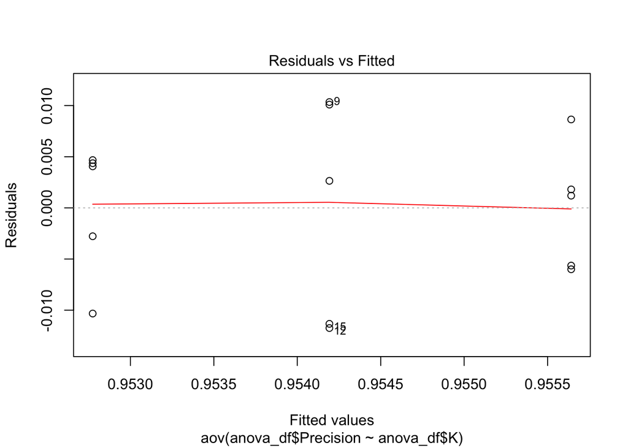

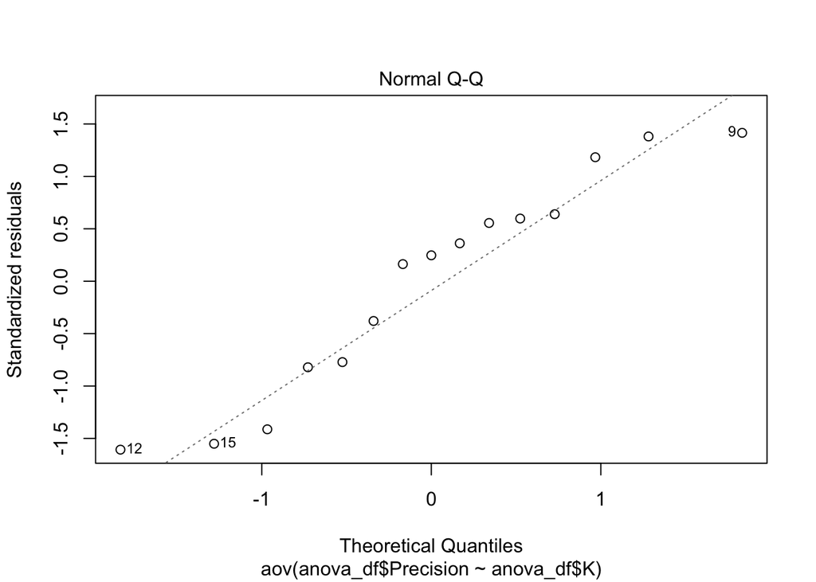

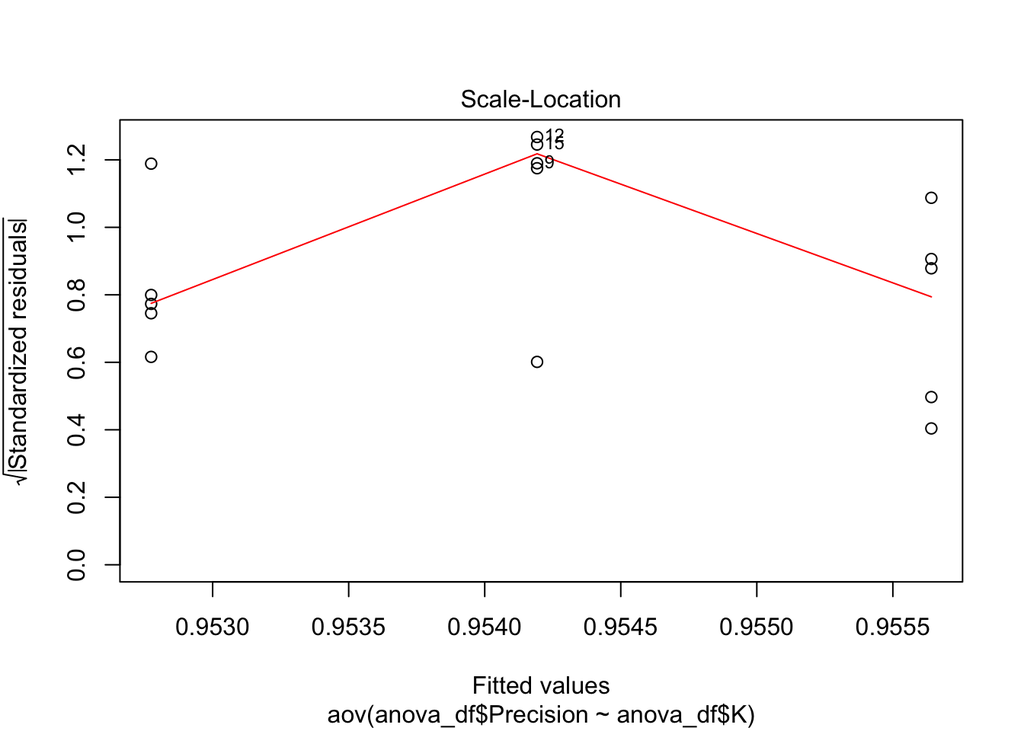

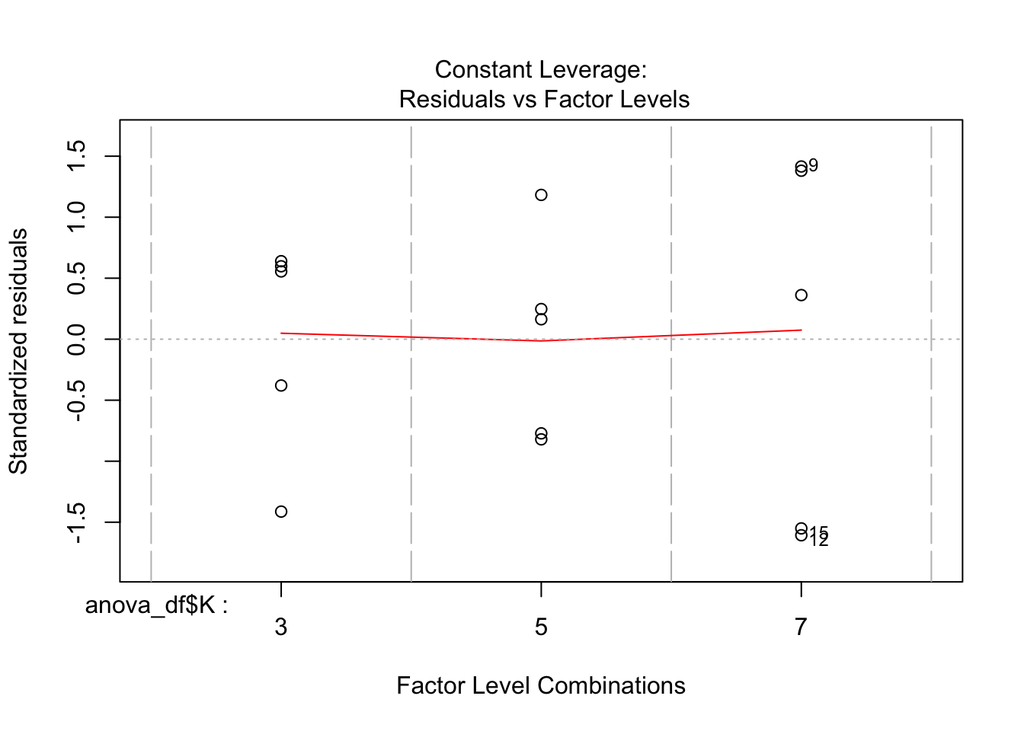

```r
plot(anova_BC)
```

Los gráficos de los residuos no muestran falta de homoscedasticidad (gráfico 1, residuals vs fitted) y en el qqplot los residuos se distribuyen muy cercanos a la linea normal (gráfico 2, Normal Q-Q).

### 7.8 Comparación múltiple.

Aunque ANOVA nos dice que las medias para k=3,5,7 no son diferentes, podemos comprobar con un test a posteriori entre pares no se van a encontrar diferencias significativas.

Vamos a utilizar un nuevo test diferente al del apartado 5 (Bonferroni, Scheffé), usaremos el de Tukey.

```r
TukeyHSD(anova_BC)
```

```
##   Tukey multiple comparisons of means
##     95% family-wise confidence level
##
## Fit: aov(formula = anova_df$Precision ~ anova_df$K, data = anova_df)
##
## $`anova_df$K`
##             diff         lwr        upr     p adj
## 5-3  0.002867420 -0.01092134 0.01665618 0.8460144
## 7-3  0.001418440 -0.01237032 0.01520720 0.9594699
## 7-5 -0.001448981 -0.01523774 0.01233978 0.9577501
```

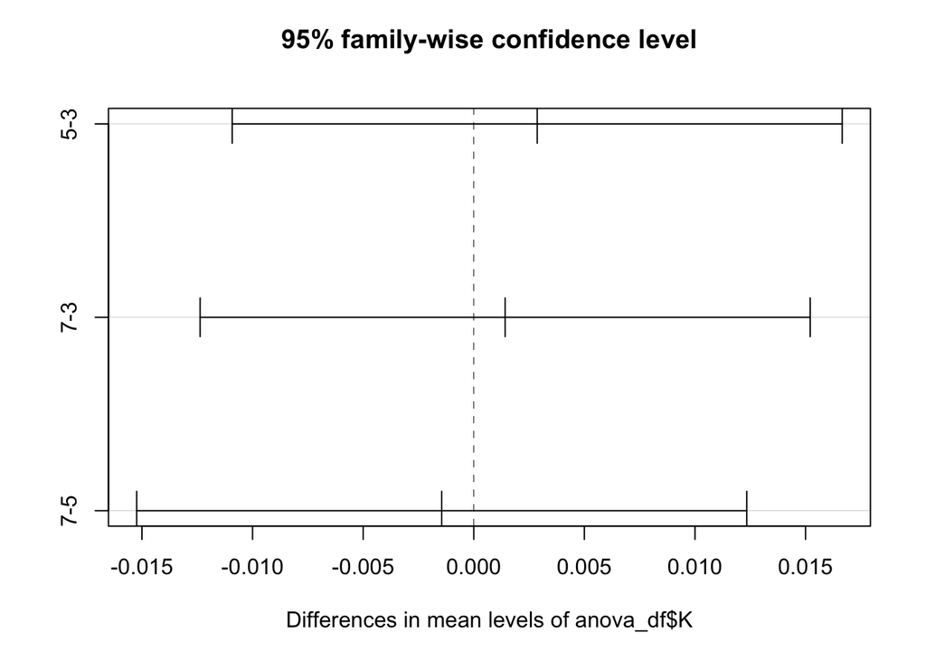

```r
plot(TukeyHSD(anova_BC))
```

Como era de esperar no se encuentran diferencias significativas entre ningún par de medias.